# Second Project. Отчет о построении первичной модели прогнозирования стоимости недвижимости в Бостоне

# 1 Введение

После того, как весь инструментарий был загружен визуально, оценим исследуемый набор данных применив функцию head(), чтобы не нагромождать вывод.

```
##      crim zn indus chas   nox    rm  age    dis rad tax ptratio  black lstat
## 1 0.00632 18  2.31    0 0.538 6.575 65.2 4.0900   1 296    15.3 396.90  4.98
## 2 0.02731  0  7.07    0 0.469 6.421 78.9 4.9671   2 242    17.8 396.90  9.14
## 3 0.02729  0  7.07    0 0.469 7.185 61.1 4.9671   2 242    17.8 392.83  4.03
## 4 0.03237  0  2.18    0 0.458 6.998 45.8 6.0622   3 222    18.7 394.63  2.94
## 5 0.06905  0  2.18    0 0.458 7.147 54.2 6.0622   3 222    18.7 396.90  5.33
## 6 0.02985  0  2.18    0 0.458 6.430 58.7 6.0622   3 222    18.7 394.12  5.21
##   medv
## 1 24.0
## 2 21.6
## 3 34.7
## 4 33.4
## 5 36.2
## 6 28.7
```

```
## 'data.frame':    506 obs. of  14 variables:
##  $ crim   : num  0.00632 0.02731 0.02729 0.03237 0.06905 ...
##  $ zn     : num  18 0 0 0 0 0 12.5 12.5 12.5 12.5 ...
##  $ indus  : num  2.31 7.07 7.07 2.18 2.18 2.18 7.87 7.87 7.87 7.87 ...
##  $ chas   : int  0 0 0 0 0 0 0 0 0 0 ...
##  $ nox    : num  0.538 0.469 0.469 0.458 0.458 0.458 0.524 0.524 0.524 0.524 ...
##  $ rm     : num  6.58 6.42 7.18 7 7.15 ...
##  $ age    : num  65.2 78.9 61.1 45.8 54.2 58.7 66.6 96.1 100 85.9 ...
##  $ dis    : num  4.09 4.97 4.97 6.06 6.06 ...
##  $ rad    : int  1 2 2 3 3 3 5 5 5 5 ...
##  $ tax    : num  296 242 242 222 222 222 311 311 311 311 ...
##  $ ptratio: num  15.3 17.8 17.8 18.7 18.7 18.7 15.2 15.2 15.2 15.2 ...
##  $ black  : num  397 397 393 395 397 ...
##  $ lstat  : num  4.98 9.14 4.03 2.94 5.33 ...
##  $ medv   : num  24 21.6 34.7 33.4 36.2 28.7 22.9 27.1 16.5 18.9 ...
```

Становится видно, что изучаемый “dataframe” содержит в себе 14 переменных, имеющих следующее содержание:

1. crim - уровень преступности на душу населения по городам;
2. zn - доля земли под жилую застройку, зонированная под участки площадью более 25000 кв. футов;
3. indus - доля акров, не относящихся к розничной торговле, на город;
4. chas - фиктивная переменная Charles River (= 1, если участок ограничивает реку; 0 если нет);
5. nox - концентрация оксидов азота (частей на 10 млн);
6. rm - среднее количество комнат в доме;
7. age - доля занятых владельцами единиц, построенных до 1940 года;
8. dis - средневзвешенное расстояние до пяти бостонских центров занятости;
9. rad - индекс доступности радиальных автомобильных дорог;
10. tax - полная ставка налога на имущество за каждые 10 000 долларов;
11. ptratio - соотношение учеников и учителей по городам;
12. black - 1000 (Bk - 0,63) ^ 2, где Bk - доля черных по городу;
13. lstat - более низкий статус населения (в процентах);
14. medv - медианная стоимость домов, занимаемых владельцами, составляет 1000 долларов.

Основной целью, поставленной в рамках данного отчета, является постройка линейной модели зависимости средней стоимости домов (переменная medv), занимаемых владельцами от различных факторов. Для достижения цели работы были утверждены следующие задачи:

- Постройте полную линейную модель, предварительно применив стандартизацию предикторов. В модели не надо учитывать взаимодействия предикторов.
- Проведите диагностику данной модели:
  - Проверка линейности взаимосвязи;
  - Проверка влиятельных наблюдений;
  - Независимость наблюдений;
  - Нормальность распределения и постоянство дисперсии.
- Постройте график предсказаний стоимости от переменной, которая обладает наибольшим по модулю коэффициентом.

# 2 Подготовка данных

Первоначально необходимо сделать несколько приготовлений для постройки модели: опредилиться с типом используемых переменных, проверить исследуемых набор данных на наличе пропущенных значений и оценить характер распределения и корреляции переменных между собой.

В описании действий, которые необходимо выполнить перед постройкой модели, не случайно было сказано об определении характера переменных. Так, из описания и взгляда на данные становится видно, что переменная chas является номинативной и, следовательно, должна быть переведина в фактор. Второй переменной, которая могла бы быть фактором является rad. Однако, если вчитаться в описание, то становится видно, что, чем больше значение rad, тем большая доступность радиальной автомобильной доорги,таким образом, данная переменная является порядковой и ее положжение является неоднозначным.В следствии этого было принято решения: не осуществлять никаких преобразований со столбцом rad до постройки первоначальной модели. Возможно, преобразования понадобятся в дальнейшем для анализа основных компонент (PCA).

Выполним все необходимые преобрназования,выведем основные статистики и проверим набор данных на наличие пропущенных значений:

1. Основные статистики:

```
##       crim                zn             indus       chas         nox
##  Min.   : 0.00632   Min.   :  0.00   Min.   : 0.46   0:471   Min.   :0.3850
##  1st Qu.: 0.08204   1st Qu.:  0.00   1st Qu.: 5.19   1: 35   1st Qu.:0.4490
##  Median : 0.25651   Median :  0.00   Median : 9.69           Median :0.5380
##  Mean   : 3.61352   Mean   : 11.36   Mean   :11.14           Mean   :0.5547
##  3rd Qu.: 3.67708   3rd Qu.: 12.50   3rd Qu.:18.10           3rd Qu.:0.6240
##  Max.   :88.97620   Max.   :100.00   Max.   :27.74           Max.   :0.8710
##        rm             age              dis              rad
##  Min.   :3.561   Min.   :  2.90   Min.   : 1.130   Min.   : 1.000
##  1st Qu.:5.886   1st Qu.: 45.02   1st Qu.: 2.100   1st Qu.: 4.000
##  Median :6.208   Median : 77.50   Median : 3.207   Median : 5.000
##  Mean   :6.285   Mean   : 68.57   Mean   : 3.795   Mean   : 9.549
##  3rd Qu.:6.623   3rd Qu.: 94.08   3rd Qu.: 5.188   3rd Qu.:24.000
##  Max.   :8.780   Max.   :100.00   Max.   :12.127   Max.   :24.000
##       tax           ptratio          black            lstat
##  Min.   :187.0   Min.   :12.60   Min.   :  0.32   Min.   : 1.73
##  1st Qu.:279.0   1st Qu.:17.40   1st Qu.:375.38   1st Qu.: 6.95
##  Median :330.0   Median :19.05   Median :391.44   Median :11.36
##  Mean   :408.2   Mean   :18.46   Mean   :356.67   Mean   :12.65
##  3rd Qu.:666.0   3rd Qu.:20.20   3rd Qu.:396.23   3rd Qu.:16.95
##  Max.   :711.0   Max.   :22.00   Max.   :396.90   Max.   :37.97
##       medv
##  Min.   : 5.00
##  1st Qu.:17.02
##  Median :21.20
##  Mean   :22.53
##  3rd Qu.:25.00
##  Max.   :50.00
```

2. Наличие пропущенных значений:

```
## [1] 0
```

3. Наличие дублирущихся строк:

```
## [1] 0
```

4. Выведем гистограммы данных разделенных в зависимости от ограничения участком реки (chas):

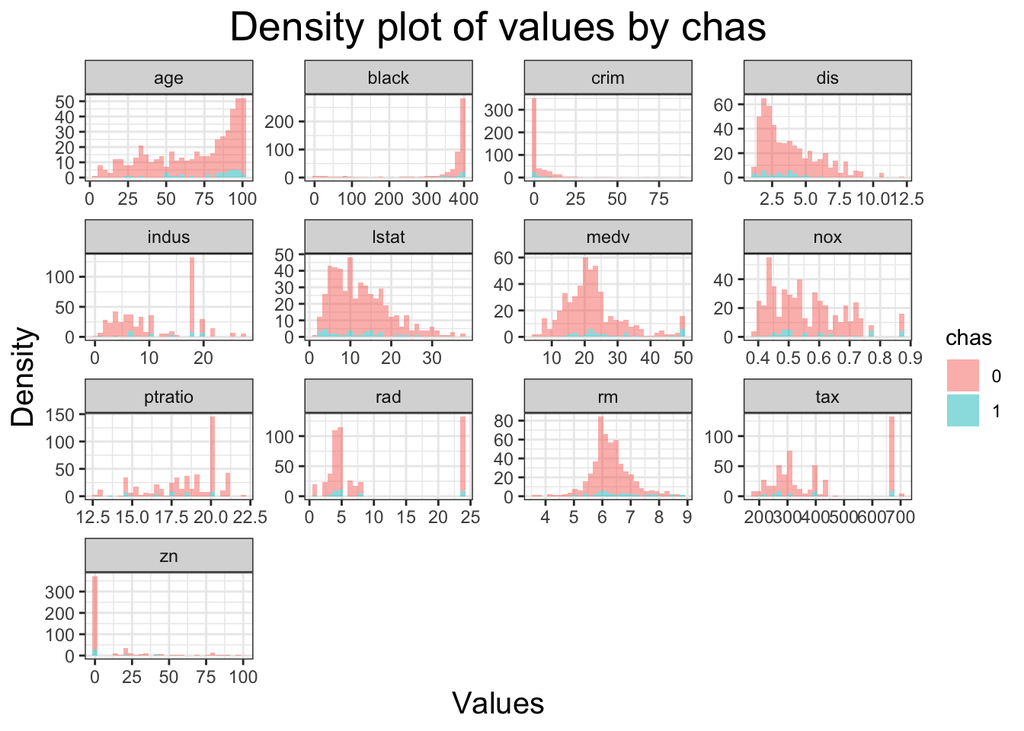

Визуализируем график разброса зависимых переменных от медианной стоимости домов:

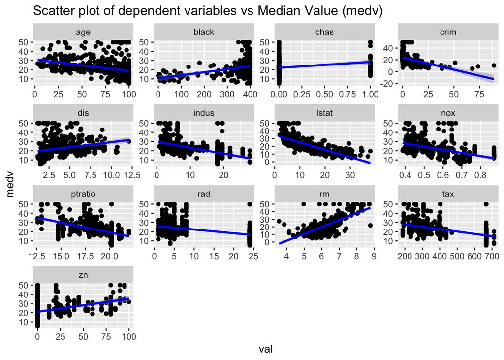

Согласно визуализации, можно судить о том, что доля домов, занимаемых владельцами, построенных до 1940 года, и доля чернокожих по городам сильно смещены влево, в то время, как уровень преступности на душу населения в городе и средневзвешенное расстояние до пяти Бостонских центров занятости сильно смещен вправо. rm обычно распределяется со средним значением примерно 6. Большинство объектов недвижимости расположены недалеко от пяти Бостонских центров занятости. 93% собственности находятся вдали от реки Чарльз. Недвижимость, граничащая с рекой, кажется, имеет более высокие средние цены.

Теперь посмотрим,как переменные соотносятся между собой через построение корреляционной матрицы:

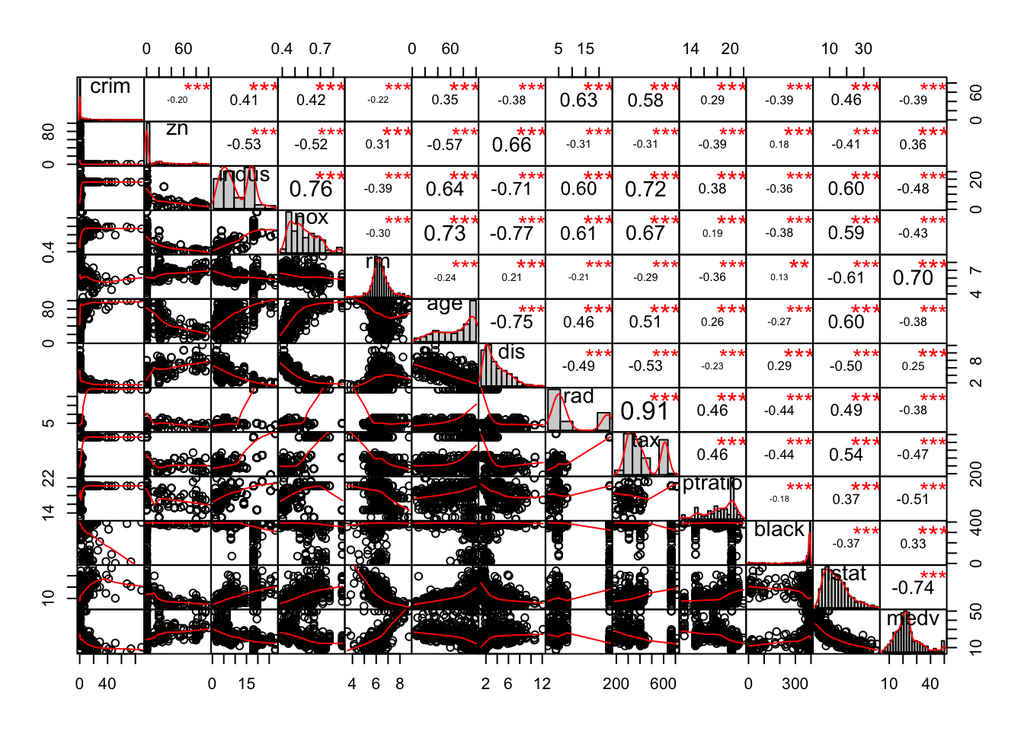

Глядя на графики корелляцийБ можно сделать вывод, что средняя стоимость домов, занимаемых владельцами увеличивается по мере увеличения среднего количества комнат на жилище и уменьшается, если процент населения с более низким статусом в этом районе увеличивается, т.е. lstat и rm показывают сильную корреляцию с medv.

Концентрация оксидов азота возрастает с увеличением доли акров, не связанных с розничной торговлей, на город и доли жилых единиц, построенных до 1940 года. Индекс доступности радиальных автомобильных дорог и полная ставка налога на имущество за каждые 10000$ долларов имеют сильную положительную корреляцию, равную 0,91, это означает, что по мере увеличения доступности радиальных автомагистралей полная стоимость налога на имущество из расчета на 10000$ также увеличивается.

Уровень преступности на душу населения по городам тесно связан с переменными rad и tax, это означает, что по мере увеличения доступности радиальных автомагистралей, уровень преступности на душу населения увеличивается.

indus имеет сильную положительную корреляцию с nox, что подтверждает мнение о высокой концентрации оксидов азота в промышленных зонах.

# 3 Построение полной линейной модели и ее оценка

## 3.1 Построение полной линейной модели

Перед тем как начать строить линейную модель необходимо стандартизироваь придикторы для того, чтобы осуществить сравнение вклада различных предикторов в линейную модель.

Построим полную регрессионную модель:

```
##
## Call:
## lm(formula = medv ~ ., data = data_scale)
##
## Residuals:
##      Min       1Q   Median       3Q      Max
## -1.69559 -0.29680 -0.05633  0.19322  2.84864
##
## Coefficients:
##              Estimate Std. Error t value Pr(>|t|)
## (Intercept) -0.020206   0.023835  -0.848 0.396976
## crim        -0.101017   0.030737  -3.287 0.001087 **
## zn           0.117715   0.034811   3.382 0.000778 ***
## indus        0.015335   0.045871   0.334 0.738288
## nox         -0.223848   0.048126  -4.651 4.25e-06 ***
## rm           0.291056   0.031928   9.116  < 2e-16 ***
## age          0.002119   0.040430   0.052 0.958229
## dis         -0.337836   0.045666  -7.398 6.01e-13 ***
## rad          0.289749   0.062813   4.613 5.07e-06 ***
## tax         -0.226032   0.068912  -3.280 0.001112 **
## ptratio     -0.224271   0.030796  -7.283 1.31e-12 ***
## black        0.092432   0.026662   3.467 0.000573 ***
## lstat       -0.407447   0.039378 -10.347  < 2e-16 ***
## chas1        0.292128   0.093679   3.118 0.001925 **
## ---
## Signif. codes:  0 '***' 0.001 '**' 0.01 '*' 0.05 '.' 0.1 ' ' 1
##
## Residual standard error: 0.516 on 492 degrees of freedom
## Multiple R-squared:  0.7406, Adjusted R-squared:  0.7338
## F-statistic: 108.1 on 13 and 492 DF,  p-value: < 2.2e-16
```

Как видно из описания модели, наиболее значимый вклад в предсказание вносит переменная lstat, что согласуется с тем фактом, что корелляция medv и lstat является наиболее сильной. Также следует отметить, что влияние переменных indus и age является не очень значимым .

Попробуем осуществить подбор наиболее значимых коофициентов для увеличения предсказательной силы модели. Автокорелляции пока что учитывать не будем:

Создадим полную и нулевую модель и осуществим подбор коофициентов при помощи метода step() с параметрами “forward” и “backward” и both и совмещенного варианта.

Для прямого отбора:

```
## Start:  AIC=1
## medv ~ 1
##
##           Df Sum of Sq    RSS     AIC
## + lstat    1   274.794 230.21 -394.51
## + rm       1   244.180 260.82 -331.33
## + ptratio  1   130.213 374.79 -147.89
## + indus    1   118.165 386.84 -131.88
## + tax      1   110.861 394.14 -122.41
## + nox      1    92.215 412.79  -99.03
## + crim     1    76.144 428.86  -79.70
## + rad      1    73.547 431.45  -76.65
## + age      1    71.758 433.24  -74.55
## + zn       1    65.610 439.39  -67.42
## + black    1    56.154 448.85  -56.65
## + dis      1    31.545 473.46  -29.64
## + chas     1    15.512 489.49  -12.79
## <none>                 505.00    1.00
##
## Step:  AIC=-394.51
## medv ~ lstat
##
##           Df Sum of Sq    RSS     AIC
## + rm       1    47.680 182.53 -509.94
## + ptratio  1    31.567 198.64 -467.13
## + chas     1     9.296 220.91 -413.36
## + dis      1     9.131 221.07 -412.99
## + age      1     3.597 226.61 -400.47
## + tax      1     3.244 226.96 -399.69
## + black    1     2.345 227.86 -397.69
## + zn       1     1.895 228.31 -396.69
## + crim     1     1.737 228.47 -396.34
## + indus    1     1.167 229.04 -395.08
## <none>                 230.21 -394.51
## + rad      1     0.297 229.91 -393.16
## + nox      1     0.057 230.15 -392.63
##
## Step:  AIC=-509.94
## medv ~ lstat + rm
##
```

[output cut: 109 more lines]

```
##
##         Df Sum of Sq    RSS     AIC
## + tax    1    3.2348 131.01 -659.75
## <none>               134.24 -649.41
## + indus  1    0.4007 133.84 -648.93
## + age    1    0.0011 134.24 -647.42
##
## Step:  AIC=-659.75
## medv ~ lstat + rm + ptratio + dis + nox + chas + black + zn +
##     crim + rad + tax
##
##         Df Sum of Sq    RSS     AIC
## <none>               131.01 -659.75
## + indus  1 0.0297628 130.98 -657.87
## + age    1 0.0007413 131.00 -657.76
```

```
##
## Call:
## lm(formula = medv ~ lstat + rm + ptratio + dis + nox + chas +
##     black + zn + crim + rad + tax, data = data_scale)
##
## Residuals:
##      Min       1Q   Median       3Q      Max
## -1.69601 -0.29777 -0.05487  0.18780  2.85278
##
## Coefficients:
##             Estimate Std. Error t value Pr(>|t|)
## (Intercept) -0.02045    0.02378  -0.860 0.390246
## lstat       -0.40573    0.03682 -11.019  < 2e-16 ***
## rm           0.29042    0.03104   9.356  < 2e-16 ***
## ptratio     -0.22281    0.03038  -7.334 9.24e-13 ***
## dis         -0.34176    0.04252  -8.037 6.84e-15 ***
## nox         -0.21893    0.04454  -4.915 1.21e-06 ***
## chas1        0.29561    0.09288   3.183 0.001551 **
## black        0.09223    0.02654   3.475 0.000557 ***
## zn           0.11626    0.03429   3.390 0.000754 ***
## crim        -0.10139    0.03066  -3.307 0.001010 **
## rad          0.28365    0.06003   4.726 3.00e-06 ***
## tax         -0.21583    0.06180  -3.493 0.000521 ***
## ---
## Signif. codes:  0 '***' 0.001 '**' 0.01 '*' 0.05 '.' 0.1 ' ' 1
##
## Residual standard error: 0.515 on 494 degrees of freedom
## Multiple R-squared:  0.7406, Adjusted R-squared:  0.7348
## F-statistic: 128.2 on 11 and 494 DF,  p-value: < 2.2e-16
```

```
## Start:  AIC=-655.87
## medv ~ crim + zn + indus + nox + rm + age + dis + rad + tax +
##     ptratio + black + lstat + chas
##
##           Df Sum of Sq    RSS     AIC
## - age      1    0.0007 130.98 -657.87
## - indus    1    0.0298 131.00 -657.76
## <none>                 130.97 -655.87
## - chas     1    2.5887 133.56 -647.97
## - tax      1    2.8640 133.84 -646.93
## - crim     1    2.8754 133.85 -646.88
## - zn       1    3.0441 134.02 -646.25
## - black    1    3.1995 134.18 -645.66
## - rad      1    5.6646 136.64 -636.45
## - nox      1    5.7592 136.74 -636.10
## - ptratio  1   14.1185 145.09 -606.07
## - dis      1   14.5698 145.54 -604.50
## - rm       1   22.1231 153.10 -578.90
## - lstat    1   28.5014 159.48 -558.25
##
## Step:  AIC=-657.87
## medv ~ crim + zn + indus + nox + rm + dis + rad + tax + ptratio +
##     black + lstat + chas
##
##           Df Sum of Sq    RSS     AIC
## - indus    1     0.030 131.01 -659.75
## <none>                 130.98 -657.87
## - chas     1     2.600 133.58 -649.92
## - tax      1     2.864 133.84 -648.93
## - crim     1     2.875 133.85 -648.88
## - zn       1     3.078 134.05 -648.12
## - black    1     3.219 134.19 -647.59
## - rad      1     5.688 136.66 -638.36
## - nox      1     6.158 137.13 -636.62
## - ptratio  1    14.189 145.17 -607.82
## - dis      1    15.987 146.96 -601.60
## - rm       1    23.166 154.14 -577.46
## - lstat    1    32.143 163.12 -548.82
##
## Step:  AIC=-659.75
## medv ~ crim + zn + nox + rm + dis + rad + tax + ptratio + black +
##     lstat + chas
##
##           Df Sum of Sq    RSS     AIC
## <none>                 131.01 -659.75
## - chas     1     2.686 133.69 -651.48
## - crim     1     2.901 133.91 -650.67
## - zn       1     3.048 134.05 -650.12
## - black    1     3.202 134.21 -649.54
## - tax      1     3.235 134.24 -649.41
## - rad      1     5.922 136.93 -639.38
## - nox      1     6.407 137.41 -637.60
## - ptratio  1    14.263 145.27 -609.46
## - dis      1    17.130 148.14 -599.57
## - rm       1    23.215 154.22 -579.20
## - lstat    1    32.198 163.20 -550.56
```

```
##
## Call:
## lm(formula = medv ~ crim + zn + nox + rm + dis + rad + tax +
##     ptratio + black + lstat + chas, data = data_scale)
##
## Residuals:
##      Min       1Q   Median       3Q      Max
## -1.69601 -0.29777 -0.05487  0.18780  2.85278
##
## Coefficients:
##             Estimate Std. Error t value Pr(>|t|)
## (Intercept) -0.02045    0.02378  -0.860 0.390246
## crim        -0.10139    0.03066  -3.307 0.001010 **
## zn           0.11626    0.03429   3.390 0.000754 ***
## nox         -0.21893    0.04454  -4.915 1.21e-06 ***
## rm           0.29042    0.03104   9.356  < 2e-16 ***
## dis         -0.34176    0.04252  -8.037 6.84e-15 ***
## rad          0.28365    0.06003   4.726 3.00e-06 ***
## tax         -0.21583    0.06180  -3.493 0.000521 ***
## ptratio     -0.22281    0.03038  -7.334 9.24e-13 ***
## black        0.09223    0.02654   3.475 0.000557 ***
## lstat       -0.40573    0.03682 -11.019  < 2e-16 ***
## chas1        0.29561    0.09288   3.183 0.001551 **
## ---
## Signif. codes:  0 '***' 0.001 '**' 0.01 '*' 0.05 '.' 0.1 ' ' 1
##
## Residual standard error: 0.515 on 494 degrees of freedom
## Multiple R-squared:  0.7406, Adjusted R-squared:  0.7348
## F-statistic: 128.2 on 11 and 494 DF,  p-value: < 2.2e-16
```

Совмещенный вариант:

```
## Start:  AIC=1
## medv ~ 1
##
##           Df Sum of Sq    RSS     AIC
## + lstat    1   274.794 230.21 -394.51
## + rm       1   244.180 260.82 -331.33
## + ptratio  1   130.213 374.79 -147.89
## + indus    1   118.165 386.84 -131.88
## + tax      1   110.861 394.14 -122.41
## + nox      1    92.215 412.79  -99.03
## + crim     1    76.144 428.86  -79.70
## + rad      1    73.547 431.45  -76.65
## + age      1    71.758 433.24  -74.55
## + zn       1    65.610 439.39  -67.42
## + black    1    56.154 448.85  -56.65
## + dis      1    31.545 473.46  -29.64
## + chas     1    15.512 489.49  -12.79
## <none>                 505.00    1.00
##
## Step:  AIC=-394.51
## medv ~ lstat
##
##           Df Sum of Sq    RSS     AIC
## + rm       1    47.680 182.53 -509.94
## + ptratio  1    31.567 198.64 -467.13
## + chas     1     9.296 220.91 -413.36
## + dis      1     9.131 221.07 -412.99
## + age      1     3.597 226.61 -400.47
## + tax      1     3.244 226.96 -399.69
## + black    1     2.345 227.86 -397.69
## + zn       1     1.895 228.31 -396.69
## + crim     1     1.737 228.47 -396.34
## + indus    1     1.167 229.04 -395.08
## <none>                 230.21 -394.51
## + rad      1     0.297 229.91 -393.16
## + nox      1     0.057 230.15 -392.63
## - lstat    1   274.794 505.00    1.00
##
## Step:  AIC=-509.94
## medv ~ lstat + rm
```

[output cut: 175 more lines]

```
##           Df Sum of Sq    RSS     AIC
## <none>                 131.01 -659.75
## + indus    1     0.030 130.98 -657.87
## + age      1     0.001 131.00 -657.76
## - chas     1     2.686 133.69 -651.48
## - crim     1     2.901 133.91 -650.67
## - zn       1     3.048 134.05 -650.12
## - black    1     3.202 134.21 -649.54
## - tax      1     3.235 134.24 -649.41
## - rad      1     5.922 136.93 -639.38
## - nox      1     6.407 137.41 -637.60
## - ptratio  1    14.263 145.27 -609.46
## - dis      1    17.130 148.14 -599.57
## - rm       1    23.215 154.22 -579.20
## - lstat    1    32.198 163.20 -550.56
```

```
##
## Call:
## lm(formula = medv ~ lstat + rm + ptratio + dis + nox + chas +
##     black + zn + crim + rad + tax, data = data_scale)
##
## Residuals:
##      Min       1Q   Median       3Q      Max
## -1.69601 -0.29777 -0.05487  0.18780  2.85278
##
## Coefficients:
##             Estimate Std. Error t value Pr(>|t|)
## (Intercept) -0.02045    0.02378  -0.860 0.390246
## lstat       -0.40573    0.03682 -11.019  < 2e-16 ***
## rm           0.29042    0.03104   9.356  < 2e-16 ***
## ptratio     -0.22281    0.03038  -7.334 9.24e-13 ***
## dis         -0.34176    0.04252  -8.037 6.84e-15 ***
## nox         -0.21893    0.04454  -4.915 1.21e-06 ***
## chas1        0.29561    0.09288   3.183 0.001551 **
## black        0.09223    0.02654   3.475 0.000557 ***
## zn           0.11626    0.03429   3.390 0.000754 ***
## crim        -0.10139    0.03066  -3.307 0.001010 **
## rad          0.28365    0.06003   4.726 3.00e-06 ***
## tax         -0.21583    0.06180  -3.493 0.000521 ***
## ---
## Signif. codes:  0 '***' 0.001 '**' 0.01 '*' 0.05 '.' 0.1 ' ' 1
##
## Residual standard error: 0.515 on 494 degrees of freedom
## Multiple R-squared:  0.7406, Adjusted R-squared:  0.7348
## F-statistic: 128.2 on 11 and 494 DF,  p-value: < 2.2e-16
```

Действительно, в данном случае без учета автокорелляций мы можем отбросить исключительно параметры indus и age, как не очень значимые.

### 3.1.1 Проверка полученной модели

Теперь, когда модель готова осуществим ее диагностику:

#### 3.1.1.1 Проверка линейности взаимосвязи

Для проверки полученной модели на линейность построим quantile-quantile plot для остатков:

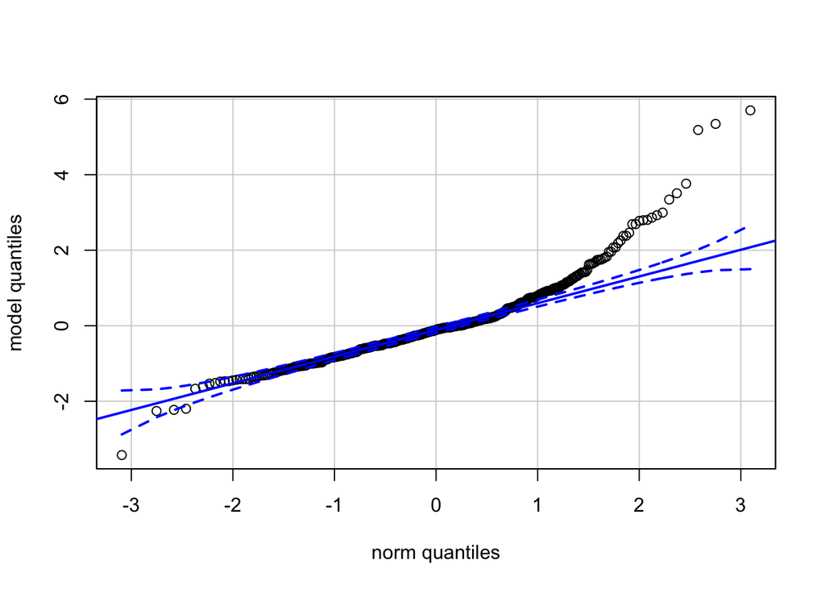

Как можно наблюдать из графика, взаимосвязь между medv и предикторами не является полностью линейной.

#### 3.1.1.2 Проверка влиятельных наблюдений

Построим график расстояний Кука:

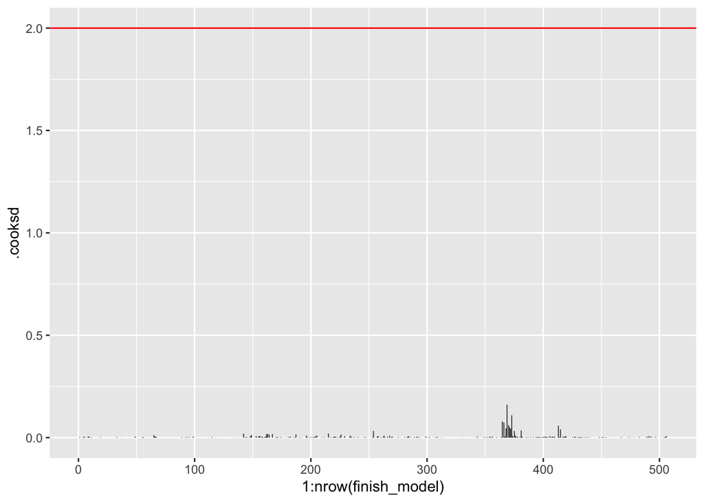

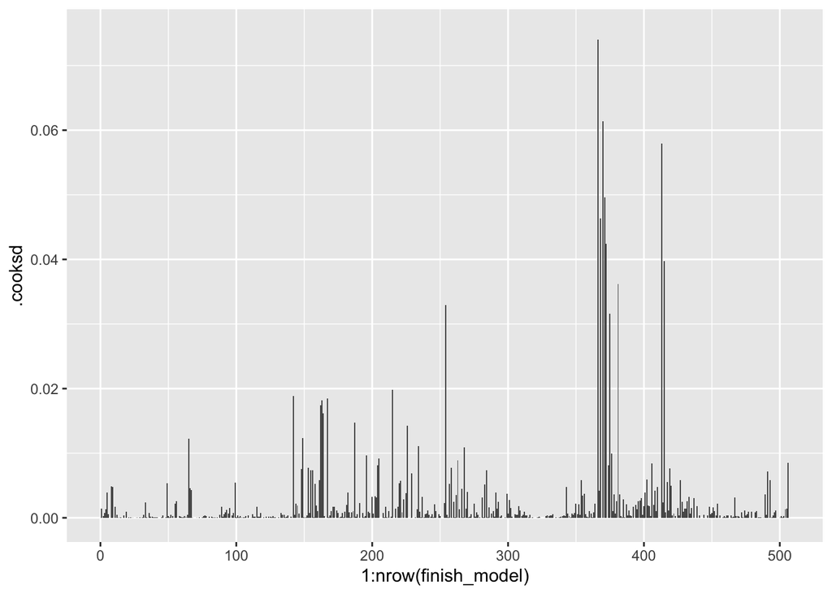

Граффик расстояний Кука демонстрирует наличие значимых наблюдений. Однако, сила их влияния не очень велика, поскольку ни одно из расстояний Кука не привышает значения в единицу.

#### 3.1.1.3 Независимость наблюдений и постоянство дисперсии

Построим график распределения остатков:

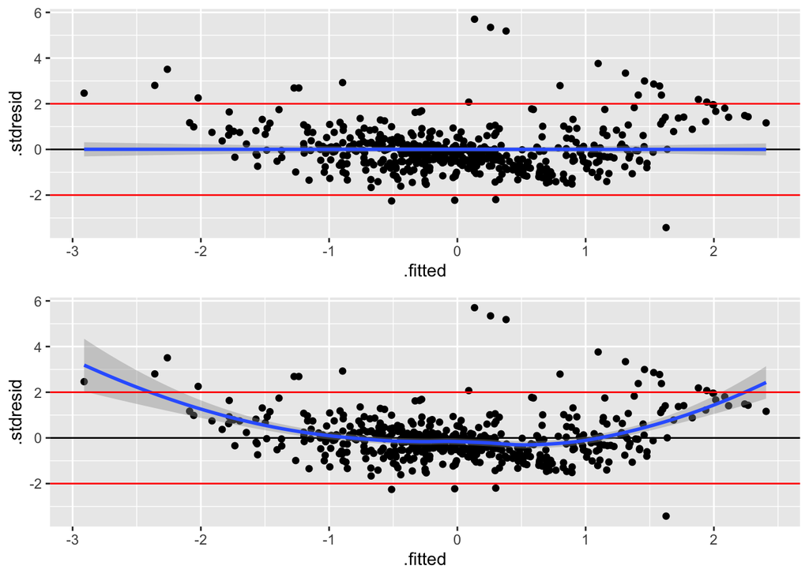

Также построим графики от предикторов, не вошедших в модель:

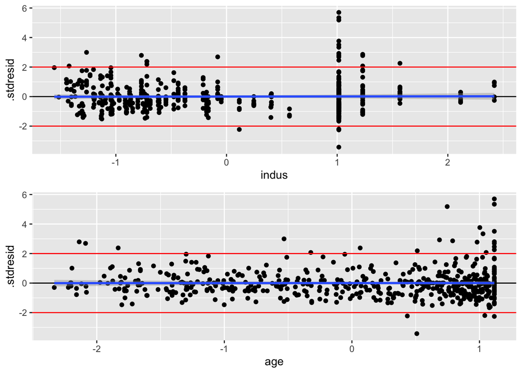

На графике остатков мы видим значительные выбросы.Можно сделать выводы о наличии автокорелляций и не гетерогенности дисперсии. Исключенные переменные не имеют скрытых влияний на модель.

# 4 Постройте график предсказаний стоимости от переменной, которая обладает наибольшим по модулю коэффициентом

Как было установленно ранее, наиболее значимой переменной в построенной линейной модели являтся более низкий статус населения.

Для того,чтобы осуществить моделирование необходимо создать искуственный набор данных. Сделаем это и выведим результаты на экран:

```
## 'data.frame':    100 obs. of  11 variables:
##  $ black  : num  -1.15e-16 -1.15e-16 -1.15e-16 -1.15e-16 -1.15e-16 ...
##  $ ptratio: num  -3.92e-16 -3.92e-16 -3.92e-16 -3.92e-16 -3.92e-16 ...
##  $ chas   : Factor w/ 1 level "0": 1 1 1 1 1 1 1 1 1 1 ...
##  $ rm     : num  -7.05e-17 -7.05e-17 -7.05e-17 -7.05e-17 -7.05e-17 ...
##  $ lstat  : num  -1.53 -1.48 -1.43 -1.38 -1.32 ...
##  $ dis    : num  1.15e-16 1.15e-16 1.15e-16 1.15e-16 1.15e-16 ...
##  $ crim   : num  -7.2e-18 -7.2e-18 -7.2e-18 -7.2e-18 -7.2e-18 ...
##  $ zn     : num  2.28e-17 2.28e-17 2.28e-17 2.28e-17 2.28e-17 ...
##  $ nox    : num  -2.15e-16 -2.15e-16 -2.15e-16 -2.15e-16 -2.15e-16 ...
##  $ rad    : num  4.8e-17 4.8e-17 4.8e-17 4.8e-17 4.8e-17 ...
##  $ tax    : num  2.02e-17 2.02e-17 2.02e-17 2.02e-17 2.02e-17 ...
```

После того, как данные смоделированы, применим на них модель и построим графики:

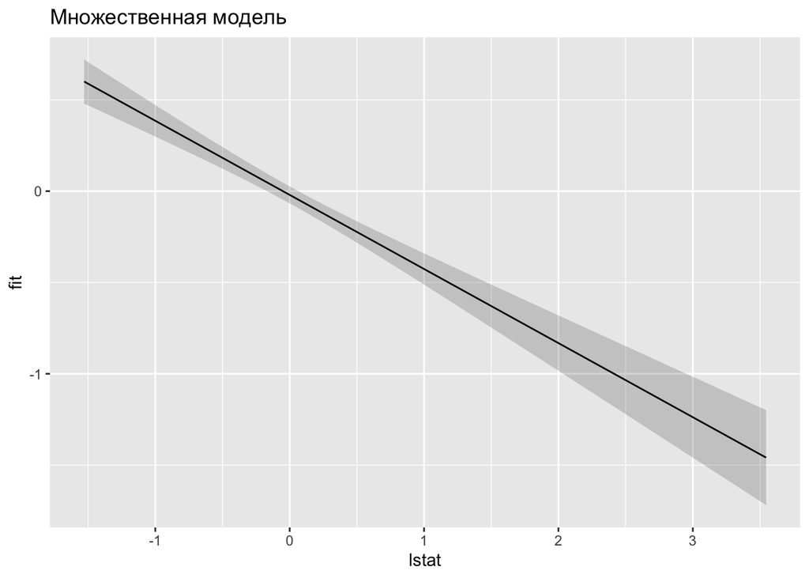

Таким образом, была получена молель предсказания стоимости от переменной, которая обладает наибольшим по модулю коэффициентом. Следует отметить, что данная модель не является рабочий в силу нелинейной связи между прогнозируем значением и предиктрами. Для увеличения качества предсказания рекомендуется применение PCA - анализа.